# EP 960 Bayesian Path analysis: Default Priors

David Kaplan

## Install necessary packages and load

install.packages(“lavaan”)

install.packages(“semTools”)

```r
library(blavaan)
library(lavaan)
library(semTools)
```

# Read in data

```r
scimodel <- read.csv("~/desktop/sciex.csv",header=T)
```

# Set up blavaan code for Model 1

```r
pathmodel1 <- '

# regressions
sciach ~ A*scigrade10
scigrade10 ~ B*scigrade6+C*ses+D*certsci+E*understand+F*challenge
challenge~G*understand
understand ~ H*certsci

# Mediation analysis

# Indirect effect of ses on SCIACH through SCIGRA10

CA := C*A


# Indirect effect off CERTSCI on SCIACH through SCIGRA10

AD := A*D

# Indirect effect off CERTSCI on SCIACH through UNDERSTD and SCIGRA10

AEH := A*E*H

# Indirect effect of CERTSCI on SCIACH through UNDERSTD CHALLG and SCIGRA10

AFGH := A*F*G*H


# Total indirect effect of CERTSCI on SCIACH

AD_AEH_AFGH := AD + AEH + AFGH

'
```

# Start estimation

```r
fitm1 <- bsem(pathmodel1, data=scimodel, burnin = 2000, sample=5000)
```

```
##
##
##
## Computing posterior predictives...
```

# Obtain diagnostics plots

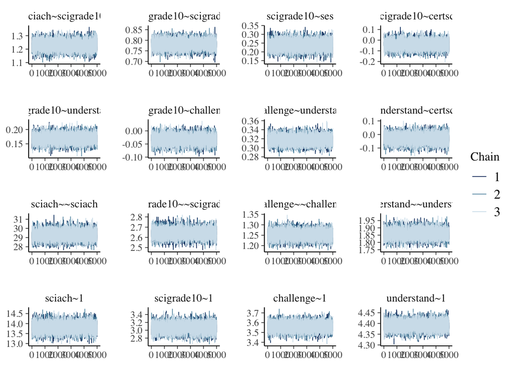

```r
M1Trace <- plot(fitm1, plot.type="trace")
```

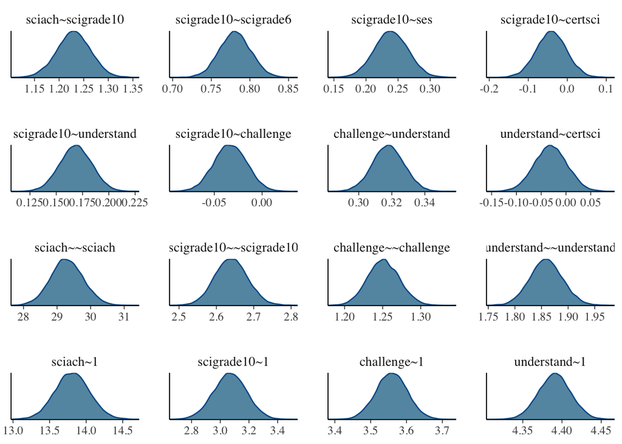

```r
M1dens <- plot(fitm1, plot.type="dens")
```

```r
M1neff <- blavInspect(fitm1, "neff")
M1neff
```

```
##                      A                      B                      C
##               10147.92               13410.58               16541.80
##                      D                      E                      F
##               20203.04               16338.67               13414.74
##                      G                      H         sciach~~sciach
##               10502.40               14055.88               22393.14
## scigrade10~~scigrade10   challenge~~challenge understand~~understand
##               22288.22               21843.77               22114.23
##               sciach~1           scigrade10~1            challenge~1
##               10169.01               11023.29               10547.53
##           understand~1
##               14337.68
```

Notice that there is reasonably good evidence of convergence of the algorithm. The trae plots have a nice horizontal band with with all chains merged. The density plots are more or less normall shapped. The effective sample size is a way to guage autocorrelcation. The effect sample size should be close to the number of actual draws that go into estimating the posterior distribution. We see that the effective sample size suggests little autocorrelation and therefore the algorithm under these settings was effective in exploring the full posterior distribution.

```r
summary(fitm1)
```

```
## blavaan (0.3-12) results of 5000 samples after 2000 adapt/burnin iterations
##
##   Number of observations                          7361
##
##   Number of missing patterns                         1
##
##   Statistic                                 MargLogLik         PPP
##   Value                                     -60982.627       0.000
##
## Regressions:
##                    Estimate  Post.SD pi.lower pi.upper     Rhat    Prior
##   sciach ~
##     scigrade10 (A)    1.230    0.034    1.162    1.295    1.000    normal(0,10)
##   scigrade10 ~
##     scigrade6  (B)    0.781    0.020    0.741     0.82    1.000    normal(0,10)
##     ses        (C)    0.239    0.026    0.188     0.29    1.000    normal(0,10)
##     certsci    (D)   -0.041    0.039   -0.117    0.035    1.000    normal(0,10)
##     understand (E)    0.169    0.015    0.139    0.198    1.000    normal(0,10)
##     challenge  (F)   -0.033    0.017   -0.067        0    1.000    normal(0,10)
##   challenge ~
##     understand (G)    0.318    0.010    0.299    0.336    1.000    normal(0,10)
##   understand ~
##     certsci    (H)   -0.031    0.033   -0.095    0.034    1.000    normal(0,10)
##
## Intercepts:
##                    Estimate  Post.SD pi.lower pi.upper     Rhat    Prior
##    .sciach           13.810    0.236   13.347   14.277    1.000    normal(0,10)
##    .scigrade10        3.068    0.115    2.841    3.292    1.000    normal(0,10)
##    .challenge         3.559    0.043    3.474    3.644    1.000    normal(0,10)
##    .understand        4.391    0.020    4.351    4.431    1.000    normal(0,10)
##
## Variances:
##                    Estimate  Post.SD pi.lower pi.upper     Rhat    Prior
##    .sciach           29.299    0.485   28.359   30.266    1.000 gamma(1,.5)[sd]
##    .scigrade10        2.640    0.044    2.555    2.727    1.000 gamma(1,.5)[sd]
##    .challenge         1.251    0.021    1.211    1.293    1.000 gamma(1,.5)[sd]
##    .understand        1.859    0.031      1.8     1.92    1.000 gamma(1,.5)[sd]
##
## Defined Parameters:
##                    Estimate  Post.SD pi.lower pi.upper     Rhat    Prior
##     CA                0.294    0.033    0.229    0.359       NA
##     AD               -0.050    0.048   -0.144    0.044       NA
##     AEH              -0.006    0.007    -0.02    0.007       NA
##     AFGH              0.000    0.001   -0.001    0.001       NA
##     AD_AEH_AFGH      -0.056    0.048    -0.15    0.039       NA
```

The output contains the posterior means, standard deviations, lower and upper bounds of the 95% posterior interval. In addition, the default (non-informative priors are presented. The prior gamma(1,5)[sd] means that this prior is being place on the standard deviation.

Notice first that the rhats are all around 1.0. This is another indicator of algorithm convergence when there is more than one chain. Here we find good mixing of the chains. Also, notice that the estimates are very close to what was obtained in the frequentist analysis. This is due in part to the non-informative priors and the rather large sample sizes. Note that with the posterior estimates and standard deviations, a rich set of follow-up analyses are possible.

# Obtain plots of model fit

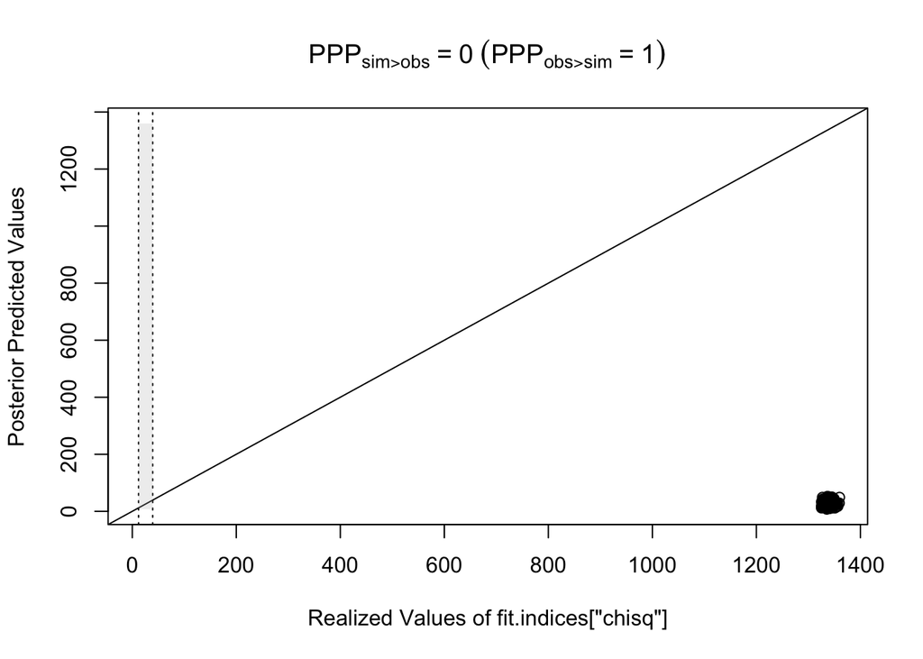

```r
M1Fit <- ppmc(fitm1, thin=10, fit.measures=c("rmsea","chisq"))
plot(M1Fit,element="chisq")
```

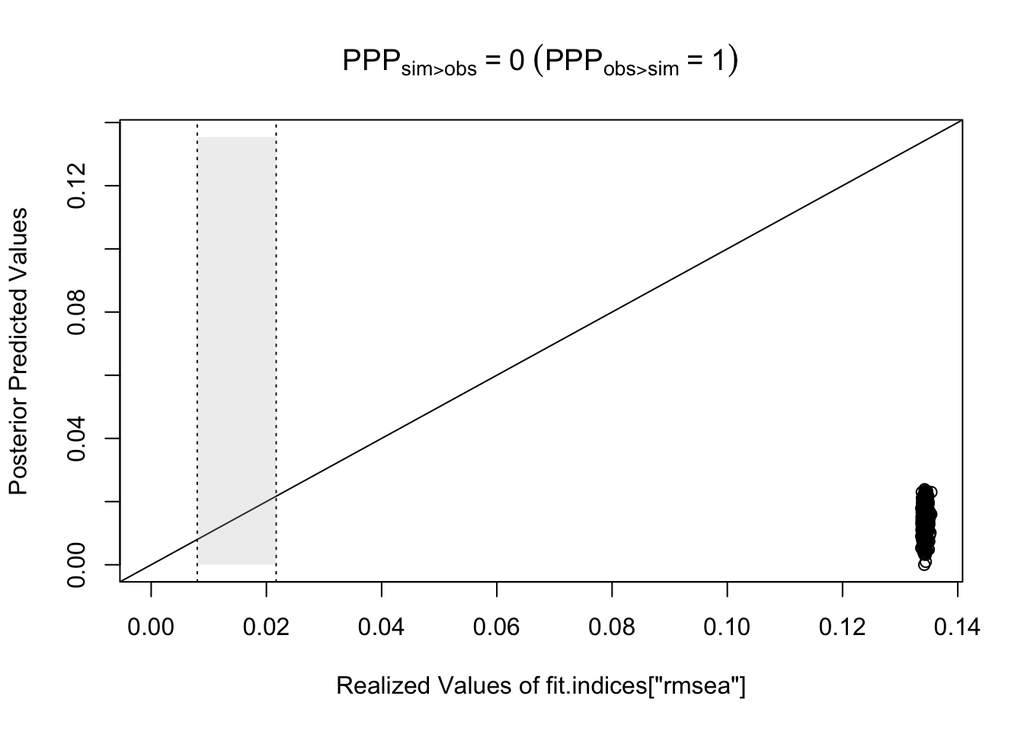

```r
plot(M1Fit,element="rmsea")
```

We notice that the model has terrible fit to the data as evidenced by the posterior predictive model checks using chi-square and RMSEA. This is consistent with the frequentist results.

# Model 2 with SES to SCIACH added

# Set up blavaan code for Model 2

```r
pathmodel2 <- '

# regressions
sciach ~ A*scigrade10 + I*ses
scigrade10 ~ B*scigrade6+C*ses+D*certsci+E*understand+F*challenge
challenge~G*understand
understand ~ H*certsci

# Mediation analysis

# Indirect effect of ses on SCIACH through SCIGRA10

CA := C*A


# Indirect effect off CERTSCI on SCIACH through SCIGRA10

AD := A*D

# Indirect effect off CERTSCI on SCIACH through UNDERSTD and SCIGRA10

AEH := A*E*H

# Indirect effect of CERTSCI on SCIACH through UNDERSTD CHALLG and SCIGRA10

AFGH := A*F*G*H


# Total indirect effect of CERTSCI on SCIACH

AD_AEH_AFGH := AD + AEH + AFGH

# Total effect of SES on SCIACH through SCIGRA10

I_CA := I + C*A

'
```

# Start estimation

```r
fitm2 <- bsem(pathmodel2, data=scimodel, burnin = 2000, sample=5000)
```

```
##
##
##
## Computing posterior predictives...
```

# Obtain diagnostics plots

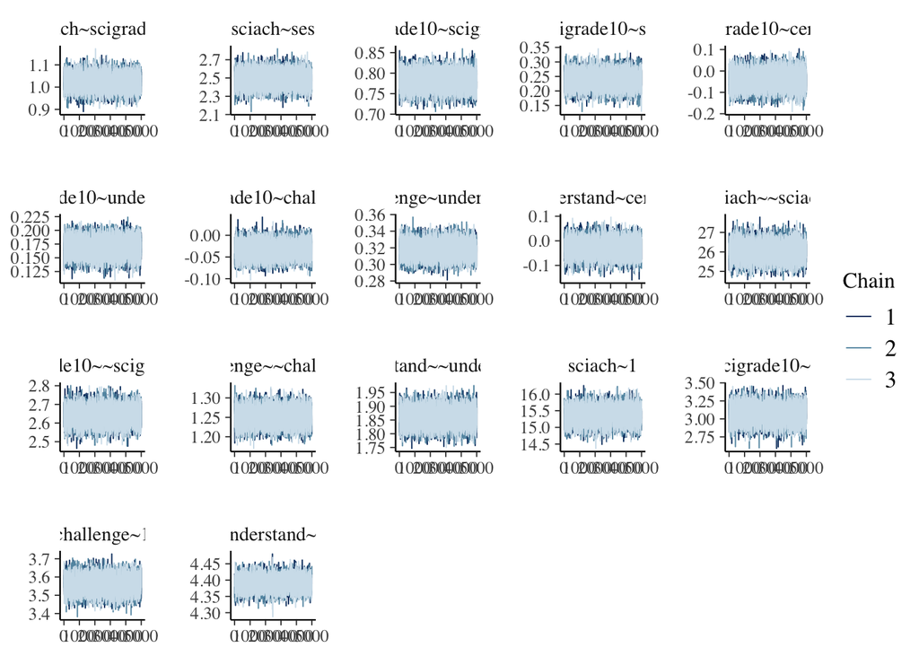

```r
M2Trace <- plot(fitm2, plot.type="trace")
```

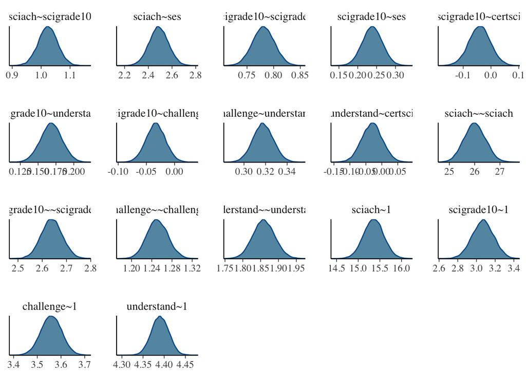

```r
M2dens <- plot(fitm2, plot.type="dens")
```

```r
M2neff <- blavInspect(fitm2, "neff")
M2neff
```

```
##                      A                      I                      B
##               8776.220              17231.519              11701.276
##                      C                      D                      E
##              16770.208              18774.746              15123.880
##                      F                      G                      H
##              14269.367               9143.841              11674.027
##         sciach~~sciach scigrade10~~scigrade10   challenge~~challenge
##              20651.419              20106.477              20783.622
## understand~~understand               sciach~1           scigrade10~1
##              19018.405               8776.524               9859.973
##            challenge~1           understand~1
##               9135.532              11348.214
```

Again, we see good evidence of convergence.

```r
summary(fitm2)
```

```
## blavaan (0.3-12) results of 5000 samples after 2000 adapt/burnin iterations
##
##   Number of observations                          7361
##
##   Number of missing patterns                         1
##
##   Statistic                                 MargLogLik         PPP
##   Value                                     -60547.821       0.000
##
## Regressions:
##                    Estimate  Post.SD pi.lower pi.upper     Rhat    Prior
##   sciach ~
##     scigrade10 (A)    1.023    0.033    0.958     1.09    1.000    normal(0,10)
##     ses        (I)    2.488    0.081    2.328    2.647    1.000    normal(0,10)
##   scigrade10 ~
##     scigrade6  (B)    0.781    0.020    0.741    0.821    1.000    normal(0,10)
##     ses        (C)    0.239    0.027    0.187    0.291    1.000    normal(0,10)
##     certsci    (D)   -0.040    0.039   -0.117    0.036    1.000    normal(0,10)
##     understand (E)    0.168    0.015    0.139    0.198    1.000    normal(0,10)
##     challenge  (F)   -0.033    0.017   -0.067        0    1.000    normal(0,10)
##   challenge ~
##     understand (G)    0.318    0.009    0.299    0.336    1.000    normal(0,10)
##   understand ~
##     certsci    (H)   -0.031    0.032   -0.094    0.033    1.000    normal(0,10)
##
## Intercepts:
##                    Estimate  Post.SD pi.lower pi.upper     Rhat    Prior
##    .sciach           15.356    0.233   14.898   15.816    1.000    normal(0,10)
##    .scigrade10        3.069    0.116    2.843    3.293    1.000    normal(0,10)
##    .challenge         3.559    0.043    3.473    3.644    1.000    normal(0,10)
##    .understand        4.390    0.020    4.351     4.43    1.000    normal(0,10)
##
## Variances:
##                    Estimate  Post.SD pi.lower pi.upper     Rhat    Prior
##    .sciach           26.009    0.425   25.196   26.844    1.000 gamma(1,.5)[sd]
##    .scigrade10        2.640    0.044    2.555    2.726    1.000 gamma(1,.5)[sd]
##    .challenge         1.251    0.021    1.211    1.293    1.000 gamma(1,.5)[sd]
##    .understand        1.859    0.031      1.8     1.92    1.000 gamma(1,.5)[sd]
##
## Defined Parameters:
##                    Estimate  Post.SD pi.lower pi.upper     Rhat    Prior
##     CA                0.244    0.028    0.189      0.3       NA
##     AD               -0.041    0.040   -0.119    0.036       NA
##     AEH              -0.005    0.006   -0.016    0.006       NA
##     AFGH              0.000    0.000   -0.001    0.001       NA
##     AD_AEH_AFGH      -0.046    0.040   -0.125    0.032       NA
##     I_CA              2.732    0.084    2.567    2.897       NA
```

# Obtain plots of model fit

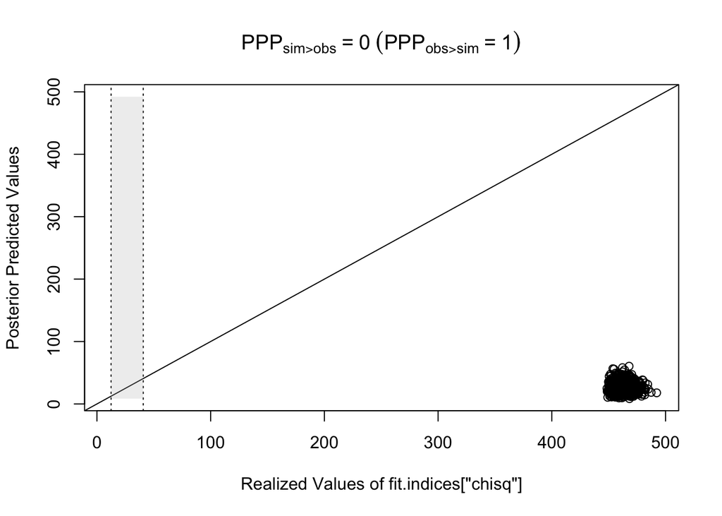

```r
M2Fit <- ppmc(fitm2, thin=10, fit.measures=c("rmsea","chisq"))
plot(M2Fit,element="chisq")
```

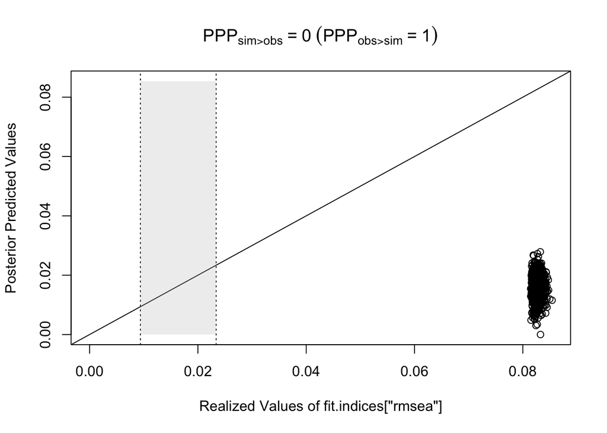

```r
plot(M2Fit,element="rmsea")
```

# Model comparison using leave-one-out cross-validation

```r
blavCompare(fitm1, fitm2)
```

```
##
## WAIC estimates:
##  object1:  121792.278
##  object2:  120917.562
##
## WAIC difference & SE:
##  -437.358   29.010
##
## LOO estimates:
##  object1:  121792.287
##  object2:  120917.572
##
## LOO difference & SE:
##  -437.357   29.010
##
## Laplace approximation to the log-Bayes factor
## (experimental; positive values favor object1): -434.805
```

We find that Model 2 has the lowest LOOIC value and is favored as the model with the best out-of-sample predictive performance.